# Practical Machine Learning Project

Sungmin Kim

June 14, 2015

# Introduction

Using devices such as Jawbone Up, Nike FuelBand, and Fitbit it is now possible to collect a large amount of data about personal activity relatively inexpensively. These type of devices are part of the quantified self movement – a group of enthusiasts who take measurements about themselves regularly to improve their health, to find patterns in their behavior, or because they are tech geeks. One thing that people regularly do is quantify how much of a particular activity they do, but they rarely quantify how well they do it. In this project, your goal will be to use data from accelerometers on the belt, forearm, arm, and dumbell of 6 participants. They were asked to perform barbell lifts correctly and incorrectly in 5 different ways.

The goal of this project is to predict the manner in which they did the exercise. We need to predict “classe” variable in the training set. In addition, we compare and contrast different prediction models with diverse diagnosis.

# Loading required packages

First of all, it is not required, but efficient to load all packages in advance before doing further analysis.

```r
library(caret)
library(rattle)
```

```r
library(ggplot2)
library(rpart)
library(randomForest)
```

# Getting and cleansing Data

```r
if(!file.exists("./data/pml-training.csv")){
  download.file(url = "https://d396qusza40orc.cloudfront.net/predmachlearn/pml-training.csv",
                destfile = "./data/pml-training.csv", method = "curl")
}
if(!file.exists("./data/pml-testing.csv")){
  download.file(url = "https://d396qusza40orc.cloudfront.net/predmachlearn/pml-testing.csv",
                destfile = "./data/pml-testing.csv", method = "curl")
}
```

After download files, we need to open them and investigate them thoroughly.

```r
data <- read.csv("pml-training.csv", na.strings = c("NA", ""))
testData <- read.csv("pml-testing.csv", na.strings = c("NA", ""))
dim(data)
```

```
## [1] 19622   160
```

We have such huge datasets, which is not necessary for our prediction models. First of all, any columns having a lot of NA values or non-related information should be excluded. Then we need to seperate data into training and test set. In our case we put 70 percent of original data into a training set and 30 percent into a test set.

```r
data <- data[, -c(1:7)] # non-related columns
filterVal <- apply(data, 2, function(x){ sum(is.na(x))})
data <- data[, which(filterVal == 0)] # filtered out NA columns
dim(data)
```

```
## [1] 19622    53
```

```r
testData <- testData[, -c(1:7)] # same as above
filterVal2 <- apply(testData, 2, function(x){ sum(is.na(x))})
testData <- testData[, which(filterVal2 == 0)] # same as above

inTrain <- createDataPartition(y = data$classe, p = 0.7, list = FALSE)
training <- data[inTrain, ]; testing <- data[-inTrain, ]
dim(training); dim(testing)
```

```
## [1] 13737    53
```

```
## [1] 5885   53
```

# Build a prediction model(Decision Tree)

Here, we build a prediction model with tree and plot it with fancier version.

```r
modFit <- train(classe ~ ., method = "rpart", data = training)
print(modFit$finalModel)
```

```
## n= 13737
##
## node), split, n, loss, yval, (yprob)
##       * denotes terminal node
##
##  1) root 13737 9831 A (0.28 0.19 0.17 0.16 0.18)
##    2) roll_belt< 130.5 12602 8704 A (0.31 0.21 0.19 0.18 0.11)
##      4) pitch_forearm< -33.65 1111   10 A (0.99 0.009 0 0 0) *
##      5) pitch_forearm>=-33.65 11491 8694 A (0.24 0.23 0.21 0.2 0.12)
##       10) magnet_dumbbell_y< 438.5 9706 6973 A (0.28 0.18 0.24 0.19 0.11)
##         20) roll_forearm< 122.5 6015 3563 A (0.41 0.18 0.18 0.17 0.062) *
##         21) roll_forearm>=122.5 3691 2467 C (0.076 0.17 0.33 0.23 0.19) *
##       11) magnet_dumbbell_y>=438.5 1785  874 B (0.036 0.51 0.041 0.22 0.19) *
##    3) roll_belt>=130.5 1135    8 E (0.007 0 0 0 0.99) *
```

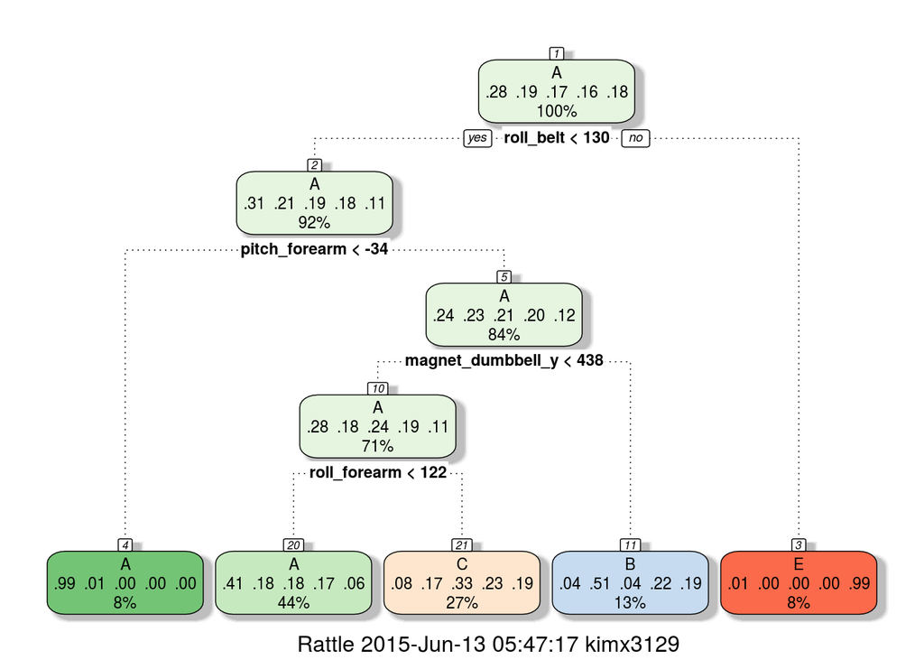

```r
fancyRpartPlot(modFit$finalModel)
```

Since we have our prediction model, we can use our test case to check the model accuracy.

```r
predictions <- predict(modFit, newdata = testing)
confusionMatrix(predictions, testing$classe)
```

```
## Confusion Matrix and Statistics
##
##           Reference
## Prediction    A    B    C    D    E
##          A 1520  458  487  439  149
##          B   23  382   35  173  153
##          C  125  299  504  352  276
##          D    0    0    0    0    0
##          E    6    0    0    0  504
##
## Overall Statistics
##
##                Accuracy : 0.4945
##                  95% CI : (0.4816, 0.5073)
##     No Information Rate : 0.2845
##     P-Value [Acc > NIR] : < 2.2e-16
##
##                   Kappa : 0.3394
##  Mcnemar's Test P-Value : NA
##
## Statistics by Class:
##
##                      Class: A Class: B Class: C Class: D Class: E
## Sensitivity            0.9080  0.33538  0.49123   0.0000  0.46580
## Specificity            0.6360  0.91909  0.78349   1.0000  0.99875
## Pos Pred Value         0.4979  0.49869  0.32391      NaN  0.98824
## Neg Pred Value         0.9456  0.85212  0.87942   0.8362  0.89247
## Prevalence             0.2845  0.19354  0.17434   0.1638  0.18386
## Detection Rate         0.2583  0.06491  0.08564   0.0000  0.08564
## Detection Prevalence   0.5188  0.13016  0.26440   0.0000  0.08666
## Balanced Accuracy      0.7720  0.62724  0.63736   0.5000  0.73228
```

# Build a prediction model(Random Forest)

Here we use Random Forest to create another prediction model and to see how accurately it predicts compared to the previous one.

```r
modFit2 <- randomForest(classe ~ ., data = training, importance = TRUE, ntree = 100)
```

Now we predict a testing set and create a confusion matrix to visualize how well our model accurately predicts.

```r
predictions2 <- predict(modFit2, newdata = testing)
confusionMatrix(predictions2, testing$classe)
```

```
## Confusion Matrix and Statistics
##
##           Reference
## Prediction    A    B    C    D    E
##          A 1673    5    0    0    0
##          B    0 1131   13    0    0
##          C    0    3 1009    8    2
##          D    0    0    4  956    1
##          E    1    0    0    0 1079
##
## Overall Statistics
##
##                Accuracy : 0.9937
##                  95% CI : (0.9913, 0.9956)
##     No Information Rate : 0.2845
##     P-Value [Acc > NIR] : < 2.2e-16
##
##                   Kappa : 0.992
##  Mcnemar's Test P-Value : NA
##
## Statistics by Class:
##
##                      Class: A Class: B Class: C Class: D Class: E
## Sensitivity            0.9994   0.9930   0.9834   0.9917   0.9972
## Specificity            0.9988   0.9973   0.9973   0.9990   0.9998
## Pos Pred Value         0.9970   0.9886   0.9873   0.9948   0.9991
## Neg Pred Value         0.9998   0.9983   0.9965   0.9984   0.9994
## Prevalence             0.2845   0.1935   0.1743   0.1638   0.1839
## Detection Rate         0.2843   0.1922   0.1715   0.1624   0.1833
## Detection Prevalence   0.2851   0.1944   0.1737   0.1633   0.1835
## Balanced Accuracy      0.9991   0.9951   0.9904   0.9953   0.9985
```

# Conclusion

We successfully predicted a ‘Classe’ value from our testing set and can conclude that Random Forest yields more accurate predictions as opposed to the classification tree model. Although Random Forest might cause some overfitting issue and is a slower algorithm, it is pretty accurate and more useful to predict with non-linear regressions such as our problem. Classification tree would be better for predicting binary decision.